# Quality comparison of customer reviews of different smartphones on online marketplaces

Nadine Obeid, Clarence Koehle, Lucas Vogt and Arturo García Luna Beltrán

18 December, 2022

# Supervised learning: Predicting with random forest

This part of the report attempts to use the results of the sentiment analysis and document embedding to train a random forest algorithm to predict reviews’ sentiment. The following dataset (15’297 x 53) has been used to train the algorithm (only the first and last dimension of the document embedded matrix are displayed):

```r
# # Read sentiment score per review
sentimentr_documents <- read.csv(here::here("script/sentiment_analysis/sentiment_data/sentimentr_per_review.csv")) %>%
  select(review_id, brand = Brand, model = Model, sentimentr_score = sentimentr_value)

# # Read document embedded matrix
embedded_documents <- select(read.csv(here::here("script/unsupervised_learning/embedding/embedding_data/embedded_documents.csv")), -X) %>%
  mutate(review_id = as.integer(rownames(.))) %>%
  relocate(review_id, .before = V1)

# Join sentiment and embedding matrix to form the dataset
dataset <- left_join(embedded_documents, sentimentr_documents,  by = "review_id") %>%
  select(-review_id)
dataset$brand <- as.factor(dataset$brand)
dataset$model <- as.factor(dataset$model)
```

```
#> 'data.frame':    15297 obs. of  5 variables:
#>  $ V1              : num  -0.293 -0.629 -0.319 -0.627 -0.278 ...
#>  $ V50             : num  0.328 0.188 0.81 0.395 0.113 ...
#>  $ brand           : Factor w/ 2 levels "Apple","Samsung": 1 1 1 1 ..
#>  $ model           : Factor w/ 20 levels "iPhone 11","iPhone 11 Pr"..
#>  $ sentimentr_score: num  0.2157 0.0709 -0.075 0.5162 0.26 ...
```

The following code has been used to train the random forest (100, 500 and 1000 trees):

```r
# # Training and testing dataset
# Split the data
set.seed(456)
split <- sample.split(dataset, SplitRatio = 0.75)
train <- subset(dataset, split == "TRUE")
test <- subset(dataset, split == "FALSE")

# # Train the model: Random forest regressor
nb_trees <- 100 # 500, 1000
fit <- randomForest(data = train,
                    sentimentr_score ~ .,
                    ntree = nb_trees,
                    mtry = 25,
                    importance=TRUE)

# Save the model
save(fit, file = paste0(here::here("script/models/randomForest/rf_", nb_trees, ".RData")))
```

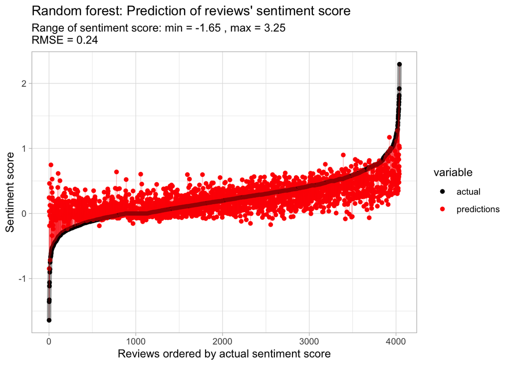

```r
# # Evaluate model accuracy on test set
predictions <- predict(fit, test[1:ncol(test)-1])
accuracy <- RMSE(predictions, test[["sentimentr_score"]])

# Data frame including actual values and predictions
results <- tibble(actual = test[["sentimentr_score"]],
                  predictions = predictions) %>%
  arrange(actual)
results["paired"] <- 1:nrow(results)
results <- melt(results, id.vars = "paired")

# Data to be plotted
set.seed(500)
plot_data <- filter(results, paired %in% sample(1:nrow(results), 5000))
plot_actual <- filter(plot_data, variable == "actual")
```

This graph shows that the random forest model is performing pretty poorly overall. It performs particularly bad when it comes to predicting extreme sentiment values. Also, it looks like it is predicting between 0.5 and -0.1 at random, no matter this input. One of the main explanation is that the training of the model is based on approximate labelling of the data. Indeed, the sentiment score is given by the `sentimentr` package which is already limited in accuracy. Also, the embedding of documents is itself based on the assumption that reviews can be summarised in 50-dimension vectors averaging the 50-dimension word vectors it contains. To improve its accuracy, it might be worth trying to increasing the number of dimensions of those vectors in addition to increasing the size of the training set. Furthermore, some improvements could be made on the sentiment score attribution. It could be that some natural language processing deep learning algorithm would perform better in capturing the sentiments of the reviews.